# M455: Pricing

Enter the password to open the deck.

## M455 Pricing

M455: Pricing

Meeting 5: Skimming, Penetration, and Freemium

Dr. Koray Cosguner

## Today’s Class

1

Pricing Strategy and Psychology

- Introduction to Pricing
- From Sticker Price to Pocket Price
- Cost, Competition, and Value-Based Pricing
- Psychological Pricing
- **Pricing Strategies** · **we are here**

2

Elasticity, Sales Response, and Optimization

3

New Product Pricing

4

Consumer Response, Targeted and Portfolio Pricing

## Skimming and Penetration

Part One

Skimming and Penetration

When to start high and come down, and when to start low and build up.

## Consider This

**June 2007:** Apple launches the iPhone 8 GB at **$599**.  
**September 2007:** Apple slashes it to **$399**, a **$200 drop in 66 days**. <sup>[1][2]</sup>

**1999:** Salesforce enters CRM at **$50/user/month** while Siebel charges **millions upfront**. <sup>[3][4]</sup>

Same goal, market dominance. Opposite strategies. How do you choose?

[1] Apple Newsroom, Sep 2007 [2] 24/7 Wall St., 2025 [3] Monetizely, 2025 [4] Medium, “How Salesforce Took Down Siebel,” 2025

## Price Skimming

Launch at a high price, then reduce it over time as the market matures.

TARGET

Early adopters with high willingness to pay.

MECHANISM

“Skim” surplus from each layer of demand before dropping to the next.

KEY INSIGHT

Works because different customers have different reservation prices.

[figure not shown]

## Discussion: Why Skim?

When does starting high make sense?

- Recoup high R&D costs quickly
- No immediate competitive threat
- Strong brand or technological differentiation
- Customers segment naturally by urgency

Price drops signal product lifecycle, not failure: the plan is built in from the start.

## Penetration Pricing

Launch at a low price to capture market share quickly, then raise prices over time.

TARGET

The mass market. Maximize adoption from day one.

MECHANISM

Sacrifice margin now to build installed base, switching costs, and scale.

KEY INSIGHT

Low price is an investment: you profit later through volume, lock-in, or network effects.

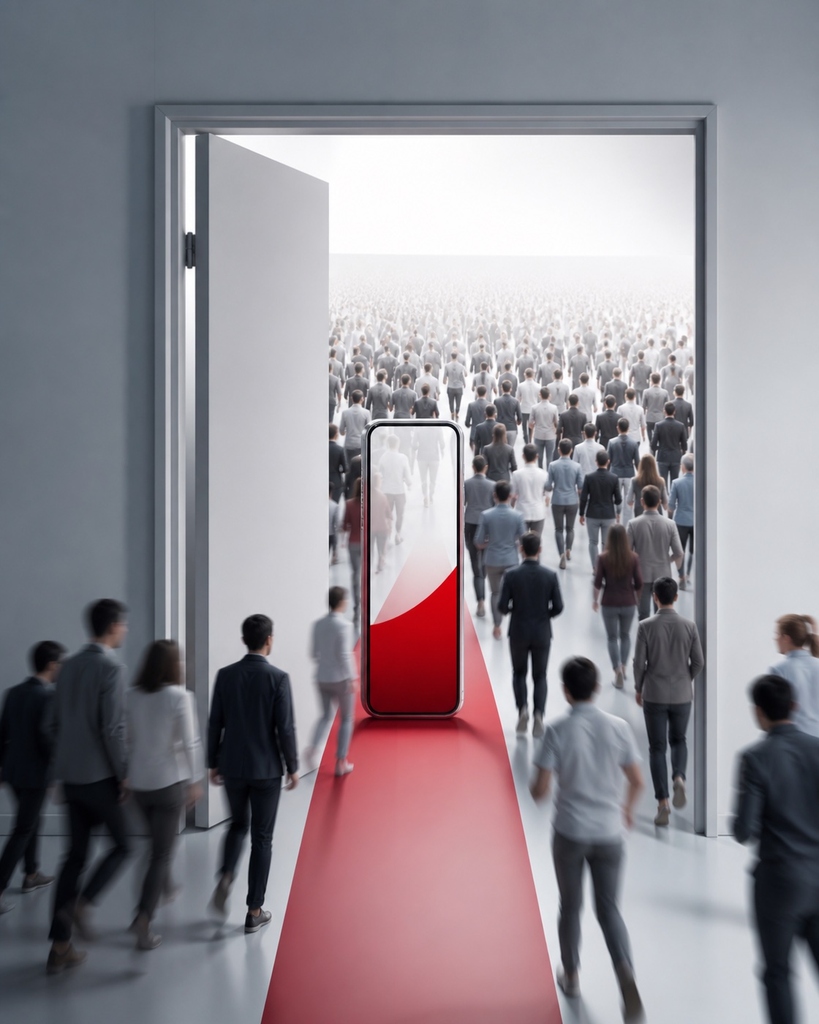

## Discussion: Why Penetrate?

When does starting low make sense?

- Strong network effects: value grows with the user base
- Low marginal costs (high fixed, low variable)
- Competitors are close behind and speed matters
- Price-elastic market: small price drops yield large demand gains

People stop comparing the options, they just get the default.

## Case Study: Apple iPhone

Jan 2007

Steve Jobs unveils the iPhone at Macworld.

Jun 2007

Launch: 4 GB at **$499**, 8 GB at **$599**. <sup>[1][2]</sup>

Sep 2007

8 GB slashed to **$399**, a **$200 drop in 66 days**. <sup>[3]</sup>

Jul 2008

iPhone 3G launches at **$199** with a carrier subsidy. <sup>[1]</sup>

**6.1 million** units sold in the first year. <sup>[2]</sup> Skimming got the development money back fast and funded the next generation.

[1] ecoATM iPhone Price History, 2025 [2] 24/7 Wall St., 2025 [3] Apple Newsroom, Sep 2007

[figure not shown]

## Case Study: Salesforce vs. Siebel

Siebel, the incumbent

**$5M+** upfront license, plus maintenance. <sup>[1]</sup>

Salesforce, the entrant

**$50/user/month**. No servers, no install. <sup>[2][3]</sup>

1999

Salesforce launches, targeting the small and mid-size firms priced out by Siebel.

2005

Siebel is acquired by Oracle. Salesforce declares victory at Dreamforce, its own user conference. <sup>[1]</sup>

2009

Salesforce revenue passes **$1 billion**. <sup>[3]</sup>

FY2025

Revenue exceeds **$35 billion**, and it now charges **$165 to $500/user/month**. <sup>[2]</sup>

[1] Medium, “How Salesforce Took Down Siebel,” 2025 [2] Monetizely, Salesforce Pricing Case Study, 2025 [3] PortersFiveForce.com, Salesforce History, 2026

## How to Choose

The decision depends on multiple factors.

| Factor | Skim | Penetrate |
| --- | --- | --- |
| Competitive threat | Low. You have time. | High. Rivals are close behind. |
| Network effects | Weak or absent | Strong. Users attract users. |
| Cost structure | High marginal costs | High fixed, low marginal |
| Price sensitivity | Low for early adopters | High across the market |

## Discussion: What Are the Risks of Skimming and Penetration?

Skimming risks

- Invites competitors attracted by your high margins
- Angers early adopters when prices drop (Apple, 2007)
- “Premium” can become “overpriced” if the gap is too large

Penetration risks

- Cash burn. You must survive long enough to raise prices.
- Customers anchor on the low price and resist increases (Netflix lost 800K subscribers in Q3 2011) <sup>[1]</sup>
- Attracts price-sensitive buyers with low lifetime value
- “Cheap” positioning can damage brand perception

[1] TIME / CNN Money, Oct 2011

## Freemium

Part Two

Freemium

Giving the product away, and how that becomes a pricing strategy.

## Consider This

**Spotify:** 751 million users. Only **290 million** pay. <sup>[1][2]</sup>

**Dropbox:** 100K to **4 million users in 15 months**, with almost no ad spend. <sup>[3]</sup>

**Zoom:** 10 million daily users to **300 million** in four months. <sup>[4][5]</sup>

All three gave the product away for free. How does that become a pricing strategy?

[1] Spotify Q4 2025 Earnings, Feb 2026 [2] CNBC, Feb 2026 [3] GrowSurf Case Study, 2024 [4] Zoom Blog, Mar 2021 [5] Engadget, Jun 2020

## Freemium Pricing

Give a basic version away for free. Monetize by converting users to a paid tier.

THE CATCH

“Free” is not just a very low price. It is psychologically different.

THE DESIGN QUESTION

Where do you draw the line between free and paid?

THE KEY METRIC

Conversion rate, typically **2 to 5%** in SaaS. <sup>[1][2]</sup>

[1] Lenny Rachitsky / OpenView Partners, 2023 (1,000+ SaaS products) [2] First Page Sage, 2026

[figure not shown]

## Where to Draw the Line

Different companies limit different things.

FEATURE-LIMITED

Spotify: ads, no offline listening, and on a phone you shuffle a playlist rather than pick a track.

CAPACITY-LIMITED

Dropbox: 2 GB free against 2 TB paid.

TIME-LIMITED

Zoom: a 40-minute cap on group meetings.

USAGE-LIMITED

Slack: 90-day message history on the free plan.

Make free useful enough to create habit, painful enough to motivate upgrading.

## Discussion: When Freemium Works

When does giving the product away make sense?

- Near-zero marginal cost to serve free users
- Product improves with use: habits, data, network effects
- Large addressable market, so even 2 to 5% conversion is profitable at scale
- Free users become your marketing. Every Zoom invite was an ad.

Freemium is a customer acquisition strategy that looks like a pricing model.

## Discussion: When Freemium Fails

When does giving the product away stop working?

- The free tier is “good enough”, so there is no reason to upgrade
- High cost to serve free users: storage, support, infrastructure
- Low viral potential. Free users do not bring other users.
- Small market, where 2 to 5% is too few paying customers

Evernote reached 150M registered users and a $1B valuation in 2012, but only a low single-digit share ever paid.

## Case Study: Spotify

2008

Launches with an ad-supported free tier in Europe.

2011

US launch. The free tier drives rapid adoption.

2024

675M monthly active users, 263M paid, about **39% conversion**. <sup>[1]</sup>

2025

751M monthly active users, 290M paid. <sup>[1]</sup>

**88%** of revenue comes from subscriptions and only **12%** from ads. The free tier is acquisition, not monetization. <sup>[2]</sup>

[1] Spotify Q4 2025 Earnings, Feb 2026 [2] Spotify SEC Filing FY2024

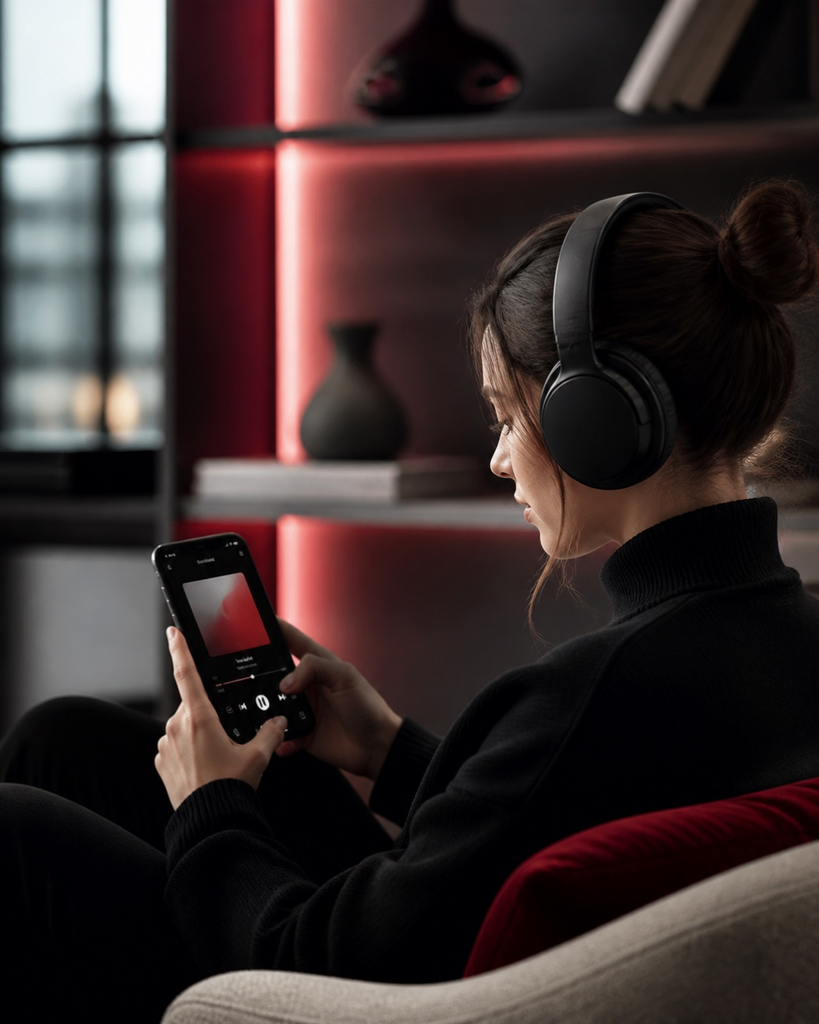

## Case Study: Atlassian

An Australian software company. It makes Jira, Confluence and Trello, the tools teams use to track their work.

2002

Founded with no salespeople. The product sells itself.

2015

IPO: 125,000+ customers, **97% acquired through the website**, no sales team. <sup>[1]</sup>

2019

Free cloud tiers for Jira and Confluence, up to 10 users. <sup>[2]</sup>

FY2025

**$5.2B** revenue, with sales and marketing only about **15%** of revenue. <sup>[3]</sup>

SaaS companies at IPO spend **50 to 100%** of revenue on sales and marketing. Atlassian spends **15%**, and **35%** on R&D. More on building than selling. <sup>[4]</sup>

[1] First Round Review [2] TechCrunch, Sep 2019 [3] Atlassian SEC Filing FY2025 [4] Tomasz Tunguz S-1 Analysis, 2015

## The Conversion Challenge

Most SaaS companies convert only 2 to 5% of free users to paid.

|  | Conversion | What drives it |
| --- | --- | --- |
| Spotify | **~39%** of active users | Habit plus pain: ads, and no picking tracks on a phone |
| Slack | **~30%** (engaged teams) | Workflow dependency plus the message limit |
| Dropbox | **~2 to 4%** | Referral-driven growth at massive scale |
| Industry median | **2 to 5%** | Based on 1,000+ SaaS products <sup>[1]</sup> |

[1] Lenny Rachitsky / OpenView Partners, 2023

## Discussion: What Are the Risks of Freemium?

You give the product away to grow. What goes wrong later?

- Free users consume real infrastructure that earns nothing
- A thin conversion rate leaves the paid base too small to fund the company
  - **Evernote:** 150M registered users and a $1B valuation in 2012, but only a low single-digit share ever paid. Layoffs in 2015 and 2018, a reported down round, and a 2022 sale to Bending Spoons for an undisclosed price. <sup>[1]</sup>
- Free attracts the wrong users: high support cost, heavy usage, low willingness to pay
- Clawing the free tier back later creates backlash, and firms do it anyway
  - **Evernote, twice:** cut to two devices in 2016, then to 50 notes in 2023 under new ownership. Both angered users. The company is profitable now. <sup>[1]</sup>
  - **Slack, July 2022:** free workspaces went from the last 10,000 messages and 5 GB of files to only 90 days, while Pro rose about 8%, its first increase since 2014. Never reversed. <sup>[2]</sup>

[1] TechCrunch 2012, 2018, 2022 · Business Insider 2015 · Engadget 2023 [2] Slack Help Center · TechCrunch, Jul 2022

## Sum Up: Skimming and Penetration

1

**Skimming** starts high and rides down the demand curve. Best when you have a real technology or brand advantage and no close substitute.

2

**Penetration** starts low to build share fast. Best when the user base makes the product more valuable, unit costs fall as volume grows, and rivals are close behind.

3

The choice is **structural, not tactical**. It depends on cost structure, competition, elasticity, and network effects.

4

Both are **launch** strategies. The price at launch shapes everything that follows.

## Sum Up: Freemium

1

Freemium is a **customer acquisition strategy** that looks like a pricing model.

2

The critical design choice is **where to draw the free/paid line**: useful enough to hook, painful enough to upgrade.

3

Typical conversion is **2 to 5%**. Standouts like Spotify and Slack convert far more through habit and dependency.

4

In B2B it **flips the sales model**. Instead of selling to an executive, one team starts using it free, it spreads, and eventually the company writes a check.

## Next Class

Meeting 6 · Bundling and Two-Part Tariffs

## Discussion

1

Netflix launched streaming at $7.99/month, classic penetration. Today Premium is $22.99 and there is an ad tier. When does a penetration strategy stop building share and start taking profit, and how do you know you have earned the right to raise prices?

## Discussion Notes

**Q1** When does penetration stop building share and start taking profit?

- MetricsChurn stays flat after a small increase. The 2011 restructure cost **800K subscribers**; by 2023 it raised prices hard and **gained** subscribers the same quarter. That gap is revealed inelasticity.
- Switching costsYou have earned it once exclusive content and habit make leaving costly. That is what billions in originals bought.
- CompetitiveNetflix could raise because by 2020 every rival was raising too. You graduate when **the industry** shifts, not just when you do.

Push “Netflix also added an ad tier at $7. Is that re-penetrating at the bottom? Can you extract at the top and penetrate at the bottom at the same time?”

## Discussion

2

You are a B2B SaaS startup. Your freemium product has 500,000 free users but only a 1.5% conversion rate. Your investors want 4%. What can you change to close that gap, and which of those changes risks killing the growth that got you 500,000 users?

## Discussion Notes

**Q2** Three moves, and the risk is not the same on each.

- Restrict the free tierCut features, add limits. Fastest, and the most likely to make people leave rather than convert.
- Improve the paid tierAdd what free users already want. Less risky, because it pulls toward value instead of pushing away.
- Change the mechanismTargeted upgrade prompts, usage-based triggers, time-limited trials of paid features.

## Discussion

3

Freemium sets the launch price at zero. Is that just penetration pricing with the price pushed all the way down, or a genuinely different strategy? Then the harder version: Netflix graduated from $7.99 to $22.99. Why can so few freemium firms make that same move?

## Discussion Notes

**Q3** Is freemium just penetration with the price at zero?

- The structurePenetration is **one price**, set low and raised later. Freemium is **two products**, one of them permanently free.
- The mechanismPenetration grows revenue by **raising the price**. Freemium grows revenue by **converting more people**. The paid price can still rise; the free tier has none to raise.
- The testNetflix grew with no free tier at all, only trials with a clock on them. Every user was already paying, so the price could rise.
- Why Spotify cannot460 million free users, no price to raise. Graduating would mean **taking something away**, a far more expensive move.